# US Car Accidents

Revealjs Presentation

Group 3: Anthony Fitch, Adib Mazloom, Annabelle Petherbridge, Julia Bautista, & William Jackson

GBA 5910, Cal Poly Pomona

2025-05-01

# Research Objective #1

What counties have the most accidents per-capita and overall. Compare these counties across multiple characteristics, age, income, etc. using US census Data.

## Operationalization of the Scale

- **Dependent Variables**
- Accidents Per Capita
  - Operationalization
    - Total Accidents per county/ Total Population of County
  - Scale Type
    - Ratio
- **Independent Variables**

| Variable | Operationalization | Scale Type |
| --- | --- | --- |
| Walk | % of workers who walk to work | Ratio |
| Drive | % who drive alone | Ratio |
| Carpool | % who carpool | Ratio |
| Transit | % who use public transit | Ratio |
| WorkAtHome | % who work remotely | Ratio |
| MeanCommute | Average commute time in minutes | Ratio |
| Professional | %employed in professional roles | Ratio |
| Service | % employed in service jobs | Ratio |
| Office | % employed in office/admin roles | Ratio |

## Data Wrangling

- Refer to: Refernce data, of bigger data sets
  - US Traffic Accident
    - Data had 7 million rows so I wrangled the data and only kept sums and tables I needed
  - US Census Data
    - Originally had 100,000 rows and wrangled it down to 14,000 rows which is all i needed based on the counties i found in the US traffic Accident data

```r
library(dplyr)
library(ggplot2)
library(readr)
library(scales)
library(patchwork)
library(tidytext)

#Read the big dataset with 7 million rows
#US_Accident_Data <- read_csv("US_Accidents.csv")

#Read Census data
#US_Census_Data <- read_csv("2017 Census Data.csv")



# Summarize and arrange
#top_counties <- US_Accident_Data %>%
 # count(County, sort = TRUE) %>%
  #top_n(20, n)

# Plot
#ggplot(top_counties, aes(x = reorder(County, n), y = n)) +
  #geom_bar(stat = "identity") +
  #coord_flip() +
  #labs(title = "Top 20 Counties by Accident Count", x = "County", y = "Count")

#top_counties_df <- top_counties %>%
  #rename(Accident_Count = n)

#print(top_counties_df)

#write.csv(top_counties_df, "top_20_counties.csv", row.names = FALSE)

Top_20_Counties <- read_csv("top_20_counties.csv")

print(Top_20_Counties)
```

```
# A tibble: 20 × 2
   County           Accident_Count
   <chr>                     <dbl>
 1 Los Angeles              526851
 2 Miami-Dade               251601
 3 Orange                   241275
 4 Harris                   181196
 5 Dallas                   157024
 6 Mecklenburg              147265
 7 Montgomery               136788
 8 Wake                     117890
 9 San Bernardino           109631
10 Travis                   107881
11 Maricopa                 106737
12 San Diego                104165
13 Alameda                   98553
14 Davidson                  96580
15 Sacramento                95377
16 Riverside                 88248
17 East Baton Rouge          75260
18 Santa Clara               70482
19 Cook                      65599
20 Marion                    59498
```

## Data Wrangling: Plot of top 20 counties with the most accidents

```r
ggplot(Top_20_Counties, aes(x = reorder(County, Accident_Count), y = Accident_Count)) +
  geom_col(fill = "steelblue") +
  geom_text(aes(label = Accident_Count), hjust = -0.1, size = 3) +
  coord_flip() +
  labs(
    title = "Top 20 Counties by Accident Count",
    x = "County",
    y = "Accident Count"
  ) +
  theme_minimal() +
  theme(plot.title = element_text(hjust = 0.5))  # Center title
```

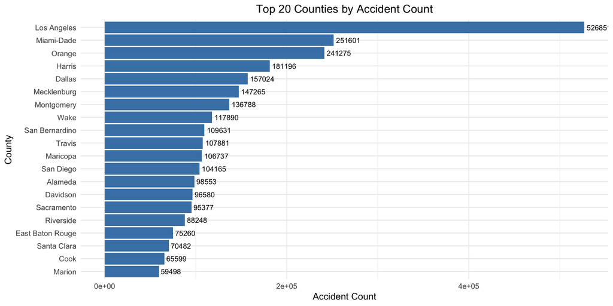

## Data Wrangling: US Census

```r
US_Census_Counties <- read_csv("US_Census_Counties.csv")

#Check for missing or inconsistent data
summary(US_Census_Counties)
```

```
    TractId             State              County             TotalPop
 Min.   :1.048e+09   Length:14711       Length:14711       Min.   :    0
 1st Qu.:6.038e+09   Class :character   Class :character   1st Qu.: 3189
 Median :1.209e+10   Mode  :character   Mode  :character   Median : 4396
 Mean   :1.892e+10                                         Mean   : 4686
 3rd Qu.:3.706e+10                                         3rd Qu.: 5782
 Max.   :5.513e+10                                         Max.   :40402

      Men            Women          Hispanic          White
 Min.   :    0   Min.   :    0   Min.   :  0.00   Min.   :  0.00
 1st Qu.: 1554   1st Qu.: 1606   1st Qu.:  7.30   1st Qu.: 16.00
 Median : 2155   Median : 2230   Median : 19.60   Median : 46.10
 Mean   : 2308   Mean   : 2378   Mean   : 29.66   Mean   : 45.34
 3rd Qu.: 2857   3rd Qu.: 2947   3rd Qu.: 46.90   3rd Qu.: 72.50
 Max.   :28658   Max.   :18062   Max.   :100.00   Max.   :100.00
                                 NA's   :71       NA's   :71
     Black            Native             Asian           Pacific
 Min.   :  0.00   Min.   :  0.0000   Min.   : 0.000   Min.   : 0.0000
 1st Qu.:  1.30   1st Qu.:  0.0000   1st Qu.: 0.800   1st Qu.: 0.0000
 Median :  4.60   Median :  0.0000   Median : 3.500   Median : 0.0000
 Mean   : 13.78   Mean   :  0.4269   Mean   : 8.151   Mean   : 0.1809
 3rd Qu.: 14.20   3rd Qu.:  0.3000   3rd Qu.:10.000   3rd Qu.: 0.0000
 Max.   :100.00   Max.   :100.0000   Max.   :89.800   Max.   :34.0000
 NA's   :71       NA's   :71         NA's   :71       NA's   :71
 VotingAgeCitizen     Income         IncomeErr       IncomePerCap
 Min.   :    0    Min.   :  5682   Min.   :   804   Min.   :   917
 1st Qu.: 2066    1st Qu.: 41295   1st Qu.:  6226   1st Qu.: 19144
 Median : 2878    Median : 58155   Median :  9121   Median : 27314
 Mean   : 3081    Mean   : 65776   Mean   : 10805   Mean   : 32279
 3rd Qu.: 3830    3rd Qu.: 82381   3rd Qu.: 13374   3rd Qu.: 39667
 Max.   :29963    Max.   :249750   Max.   :153365   Max.   :202920
                  NA's   :158      NA's   :158      NA's   :79
 IncomePerCapErr    Poverty        ChildPoverty     Professional
 Min.   :  215   Min.   :  0.00   Min.   :  0.00   Min.   :  0.00
 1st Qu.: 2491   1st Qu.:  6.90   1st Qu.:  5.80   1st Qu.: 22.80
 Median : 3543   Median : 12.90   Median : 16.60   Median : 34.80
 Mean   : 4589   Mean   : 16.18   Mean   : 21.27   Mean   : 36.94
 3rd Qu.: 5420   3rd Qu.: 22.90   3rd Qu.: 33.00   3rd Qu.: 49.80
 Max.   :52283   Max.   :100.00   Max.   :100.00   Max.   :100.00
 NA's   :79      NA's   :106      NA's   :165      NA's   :99
```

[output cut: 25 more lines]

```
 Min.   :  0.00   Min.   :  0.00   Min.   : 0.000   Min.   :0.0000
 1st Qu.: 76.60   1st Qu.:  7.90   1st Qu.: 4.000   1st Qu.:0.0000
 Median : 81.40   Median : 11.40   Median : 6.100   Median :0.0000
 Mean   : 80.55   Mean   : 12.53   Mean   : 6.764   Mean   :0.1551
 3rd Qu.: 85.60   3rd Qu.: 15.70   3rd Qu.: 8.700   3rd Qu.:0.0000
 Max.   :100.00   Max.   :100.00   Max.   :58.800   Max.   :9.8000
 NA's   :99       NA's   :99       NA's   :99       NA's   :99
  Unemployment
 Min.   : 0.000
 1st Qu.: 4.200
 Median : 6.300
 Mean   : 7.473
 3rd Qu.: 9.400
 Max.   :92.800
 NA's   :99
```

```r
colSums(is.na(US_Census_Counties))
```

```
         TractId            State           County         TotalPop
               0                0                0                0
             Men            Women         Hispanic            White
               0                0               71               71
           Black           Native            Asian          Pacific
              71               71               71               71
VotingAgeCitizen           Income        IncomeErr     IncomePerCap
               0              158              158               79
 IncomePerCapErr          Poverty     ChildPoverty     Professional
              79              106              165               99
         Service           Office     Construction       Production
              99               99               99               99
           Drive          Carpool          Transit             Walk
              94               94               94               94
     OtherTransp       WorkAtHome      MeanCommute         Employed
              94               94              126                0
     PrivateWork       PublicWork     SelfEmployed       FamilyWork
              99               99               99               99
    Unemployment
              99
```

```r
#US_Census_Counties <- US_Census_Counties %>%
  #mutate(across(c(Walk, Drive, Carpool, Transit, WorkAtHome), ~ ./100))

County_Pop_Summary <- US_Census_Counties %>%
  group_by(County) %>%
  summarise(Total_Population = sum(TotalPop, na.rm = TRUE)) %>%
  arrange(desc(Total_Population))
```

## Data Wrangling: Finding top County Populations

```r
ggplot(County_Pop_Summary, aes(x = reorder(County, Total_Population), y = Total_Population)) +
  geom_bar(stat = "identity", fill = "steelblue") +
  coord_flip() +
  scale_y_continuous(labels = comma) +  # Use commas, not scientific notation
  labs(
    title = "Total Population by County",
    x = "County",
    y = "Total Population"
  ) +
  theme_minimal() +
  theme(
    plot.title = element_text(hjust = 0.5)
  )
```

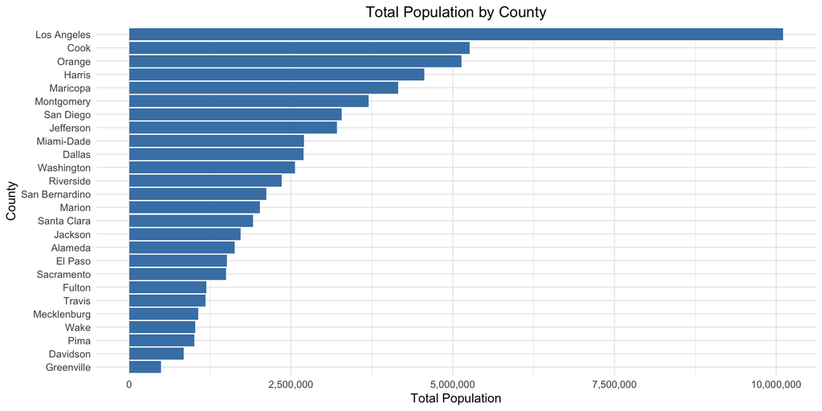

## Data Wrangling: Merging Datasets Total Accidents and Total Population

```r
Top_20_Counties_with_Pop <- Top_20_Counties %>%
  left_join(County_Pop_Summary %>% select(County, Total_Population), by = "County")

Top_20_Counties_with_Pop <- Top_20_Counties_with_Pop %>%
  mutate(Accidents_Per_Capita = Accident_Count / Total_Population)

print(Top_20_Counties_with_Pop)
```

```
# A tibble: 20 × 4
   County           Accident_Count Total_Population Accidents_Per_Capita
   <chr>                     <dbl>            <dbl>                <dbl>
 1 Los Angeles              526851         10105722               0.0521
 2 Miami-Dade               251601          2702602               0.0931
 3 Orange                   241275          5133716               0.0470
 4 Harris                   181196          4558717               0.0397
 5 Dallas                   157024          2697858               0.0582
 6 Mecklenburg              147265          1065249               0.138
 7 Montgomery               136788          3697587               0.0370
 8 Wake                     117890          1023811               0.115
 9 San Bernardino           109631          2121220               0.0517
10 Travis                   107881          1176584               0.0917
11 Maricopa                 106737          4155501               0.0257
12 San Diego                104165          3283665               0.0317
13 Alameda                   98553          1629615               0.0605
14 Davidson                  96580           842440               0.115
15 Sacramento                95377          1495400               0.0638
16 Riverside                 88248          2355002               0.0375
17 East Baton Rouge          75260               NA              NA
18 Santa Clara               70482          1911226               0.0369
19 Cook                      65599          5261001               0.0125
20 Marion                    59498          2018526               0.0295
```

## Variable: Graph Showing Total Accident Counts per County

```r
top_15_count <- Top_20_Counties_with_Pop %>%
  arrange(desc(Accident_Count)) %>%
  slice_head(n = 15) %>%
  mutate(County = factor(County, levels = rev(County)))  # fix order

plot1 <- ggplot(top_15_count, aes(x = County, y = Accident_Count, fill = County)) +
  geom_col() +
  coord_flip() +
  labs(
    title = "Top 15 Counties by Total Accident Count",
    x = "County",
    y = "Accident Count"
  ) +
  theme_minimal() +
  theme(legend.position = "none", plot.title = element_text(hjust = 0.5))
print(plot1)
```

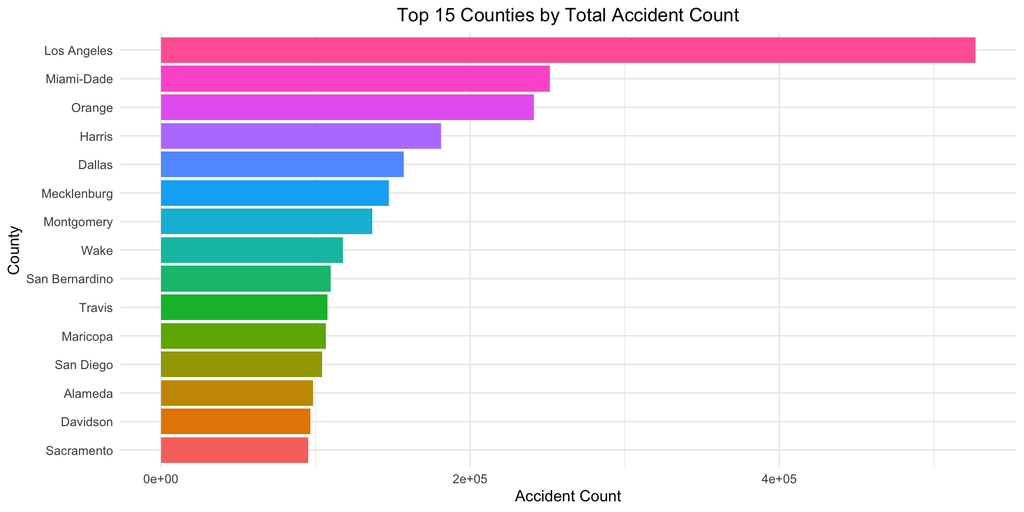

## Variable: Showing Per Capita which of the Top Counties are the worst

```r
top_15_per_capita <- Top_20_Counties_with_Pop %>%
  arrange(desc(Accidents_Per_Capita)) %>%
  slice_head(n = 15) %>%
  mutate(County = factor(County, levels = rev(County)))  # fix order

plot2 <- ggplot(top_15_per_capita, aes(x = County, y = Accidents_Per_Capita, fill = County)) +
  geom_col() +
  coord_flip() +
  labs(
    title = "Top 15 Counties by Accidents Per Capita",
    x = "County",
    y = "Accidents per Capita"
  ) +
  theme_minimal() +
  theme(legend.position = "none", plot.title = element_text(hjust = 0.5))

print(plot2)
```

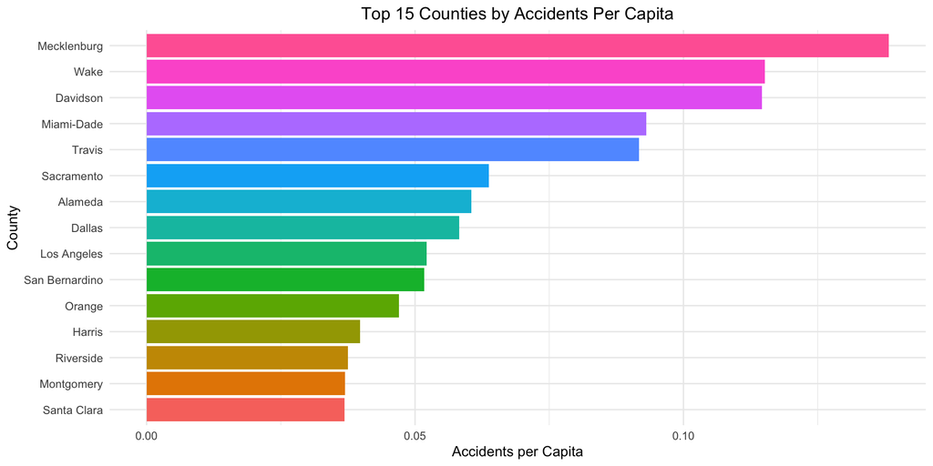

## Data Visualization: Graph of Per Capita and % of Walkers

```r
# Step 1: Define counties of interest
selected_counties <- c(
  "Los Angeles", "Miami-Dade", "Orange", "Harris", "Dallas", "Mecklenburg",
  "Montgomery", "Wake", "San Bernardino", "Travis", "Maricopa",
  "San Diego", "Alameda", "Davidson", "Sacramento"
)

# Step 2: Walk data
walk_df <- US_Census_Counties %>%
  filter(County %in% selected_counties) %>%
  group_by(County) %>%
  summarise(Value = mean(Walk, na.rm = TRUE)) %>%
  mutate(Metric = "Average Walk (%)")

# Step 3: Accident data (this determines the order)
accident_df <- Top_20_Counties_with_Pop %>%
  filter(County %in% selected_counties) %>%
  transmute(County, Value = Accidents_Per_Capita, Metric = "Accidents per Capita")

# Step 4: Set county order based on descending Accidents per Capita
county_order <- accident_df %>%
  arrange(desc(Value)) %>%
  pull(County)

# Step 5: Combine both and apply consistent order
combined_df <- bind_rows(walk_df, accident_df) %>%
  mutate(County = factor(County, levels = rev(county_order)))  # reverse for coord_flip()

# Step 6: Plot
ggplot(combined_df, aes(x = County, y = Value, fill = County)) +
  geom_col(show.legend = FALSE) +
  coord_flip() +
  facet_wrap(~ Metric, scales = "free_x", nrow = 1) +
  labs(
    title = "County Comparison: Accidents per Capita vs. Walk Percentage",
    x = "County",
    y = "Value"
  ) +
  theme_minimal() +
  theme(
    plot.title = element_text(hjust = 0.5),
    strip.text = element_text(face = "bold", size = 12)
  )
```

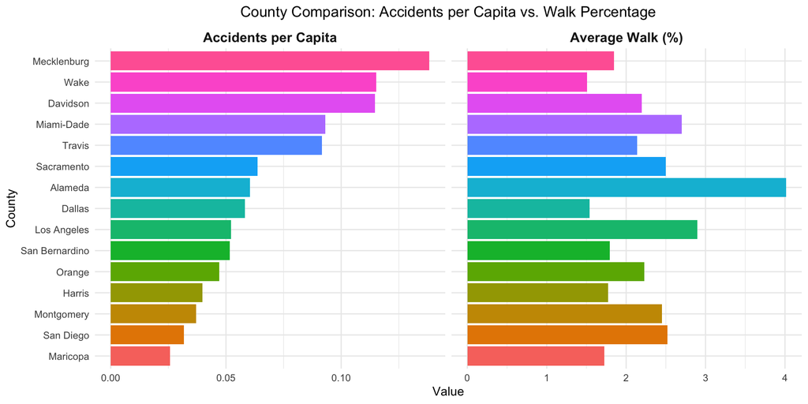

## Data Visuzliation: Graph of Per Capita and % Work From Home

```r
# Step 1: Define selected counties
selected_counties <- c(
  "Los Angeles", "Miami-Dade", "Orange", "Harris", "Dallas", "Mecklenburg",
  "Montgomery", "Wake", "San Bernardino", "Travis", "Maricopa",
  "San Diego", "Alameda", "Davidson", "Sacramento"
)

# Step 2: Work-from-home data
wfh_df <- US_Census_Counties %>%
  filter(County %in% selected_counties) %>%
  group_by(County) %>%
  summarise(Value = mean(WorkAtHome, na.rm = TRUE)) %>%
  mutate(Metric = "Average Work-from-Home (%)")

# Step 3: Accident per capita data (for ordering)
accident_df <- Top_20_Counties_with_Pop %>%
  filter(County %in% selected_counties) %>%
  transmute(County, Value = Accidents_Per_Capita, Metric = "Accidents per Capita")

# Step 4: Define County order based on descending Accidents per Capita
county_order <- accident_df %>%
  arrange(desc(Value)) %>%
  pull(County)

# Step 5: Combine datasets and apply consistent factor order
combined_df <- bind_rows(wfh_df, accident_df) %>%
  mutate(County = factor(County, levels = rev(county_order)))  # reverse for coord_flip

# Step 6: Create side-by-side plot
ggplot(combined_df, aes(x = County, y = Value, fill = County)) +
  geom_col(show.legend = FALSE) +
  coord_flip() +
  facet_wrap(~ Metric, scales = "free_x", nrow = 1) +
  labs(
    title = "County Comparison: Accidents per Capita vs. Work-from-Home Percentage",
    x = "County",
    y = "Value"
  ) +
  theme_minimal() +
  theme(
    plot.title = element_text(hjust = 0.5),
    strip.text = element_text(face = "bold", size = 12)
  )
```

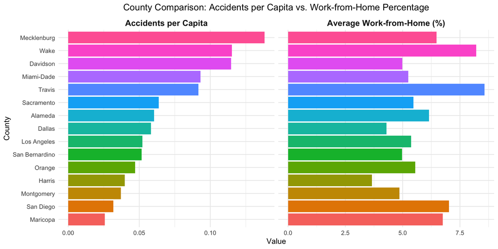

## Data Visualization: Graph with Per capita and Carpool

```r
# Step 1: Define selected counties
selected_counties <- c(
  "Los Angeles", "Miami-Dade", "Orange", "Harris", "Dallas", "Mecklenburg",
  "Montgomery", "Wake", "San Bernardino", "Travis", "Maricopa",
  "San Diego", "Alameda", "Davidson", "Sacramento"
)

# Step 2: Carpool data
carpool_df <- US_Census_Counties %>%
  filter(County %in% selected_counties) %>%
  group_by(County) %>%
  summarise(Value = mean(Carpool, na.rm = TRUE)) %>%
  mutate(Metric = "Average Carpool (%)")

# Step 3: Accident per capita data (used for ordering)
accident_df <- Top_20_Counties_with_Pop %>%
  filter(County %in% selected_counties) %>%
  transmute(County, Value = Accidents_Per_Capita, Metric = "Accidents per Capita")

# Step 4: Define County order by descending Accidents per Capita
county_order <- accident_df %>%
  arrange(desc(Value)) %>%
  pull(County)

# Step 5: Combine both datasets and enforce consistent County order
combined_df <- bind_rows(carpool_df, accident_df) %>%
  mutate(County = factor(County, levels = rev(county_order)))  # reversed for coord_flip()

# Step 6: Create faceted plot
ggplot(combined_df, aes(x = County, y = Value, fill = County)) +
  geom_col(show.legend = FALSE) +
  coord_flip() +
  facet_wrap(~ Metric, scales = "free_x", nrow = 1) +
  labs(
    title = "County Comparison: Accidents per Capita vs. Carpool Percentage",
    x = "County",
    y = "Value"
  ) +
  theme_minimal() +
  theme(
    plot.title = element_text(hjust = 0.5),
    strip.text = element_text(face = "bold", size = 12)
  )
```

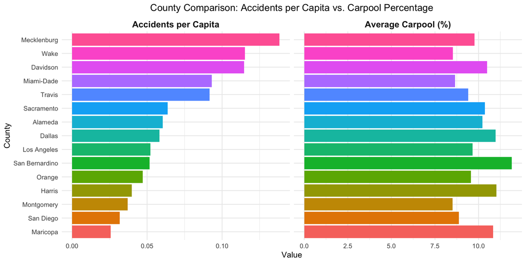

## Data Visuzliation: Graph with per Capita and % of Professional Jobs

```r
# Step 1: Define selected counties
selected_counties <- c(
  "Los Angeles", "Miami-Dade", "Orange", "Harris", "Dallas", "Mecklenburg",
  "Montgomery", "Wake", "San Bernardino", "Travis", "Maricopa",
  "San Diego", "Alameda", "Davidson", "Sacramento"
)

# Step 2: Professional employment data
professional_df <- US_Census_Counties %>%
  filter(County %in% selected_counties) %>%
  group_by(County) %>%
  summarise(Value = mean(Professional, na.rm = TRUE)) %>%
  mutate(Metric = "Average Professional Employment (%)")

# Step 3: Accident per capita data (used for ordering)
accident_df <- Top_20_Counties_with_Pop %>%
  filter(County %in% selected_counties) %>%
  transmute(County, Value = Accidents_Per_Capita, Metric = "Accidents per Capita")

# Step 4: Set County order based on descending Accidents per Capita
county_order <- accident_df %>%
  arrange(desc(Value)) %>%
  pull(County)

# Step 5: Combine both datasets with shared County factor levels
combined_df <- bind_rows(professional_df, accident_df) %>%
  mutate(County = factor(County, levels = rev(county_order)))  # reversed for coord_flip()

# Step 6: Create the side-by-side faceted plot
ggplot(combined_df, aes(x = County, y = Value, fill = County)) +
  geom_col(show.legend = FALSE) +
  coord_flip() +
  facet_wrap(~ Metric, scales = "free_x", nrow = 1) +
  labs(
    title = "County Comparison: Accidents per Capita vs. Professional Employment",
    x = "County",
    y = "Value"
  ) +
  theme_minimal() +
  theme(
    plot.title = element_text(hjust = 0.5),
    strip.text = element_text(face = "bold", size = 12)
  )
```

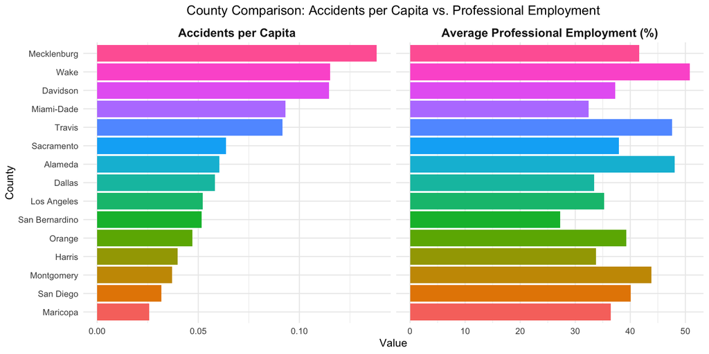

## Data Visualization: Graph of Per Capita and Service Jobs

```r
# Step 1: Define selected counties
selected_counties <- c(
  "Los Angeles", "Miami-Dade", "Orange", "Harris", "Dallas", "Mecklenburg",
  "Montgomery", "Wake", "San Bernardino", "Travis", "Maricopa",
  "San Diego", "Alameda", "Davidson", "Sacramento"
)

# Step 2: Service employment data
service_df <- US_Census_Counties %>%
  filter(County %in% selected_counties) %>%
  group_by(County) %>%
  summarise(Value = mean(Service, na.rm = TRUE)) %>%
  mutate(Metric = "Average Service Employment (%)")

# Step 3: Accidents per capita data (used for ordering)
accident_df <- Top_20_Counties_with_Pop %>%
  filter(County %in% selected_counties) %>%
  transmute(County, Value = Accidents_Per_Capita, Metric = "Accidents per Capita")

# Step 4: Set County order based on descending Accidents per Capita
county_order <- accident_df %>%
  arrange(desc(Value)) %>%
  pull(County)

# Step 5: Combine both datasets and apply the same county order
combined_df <- bind_rows(service_df, accident_df) %>%
  mutate(County = factor(County, levels = rev(county_order)))  # reversed for coord_flip()

# Step 6: Create the side-by-side faceted plot
ggplot(combined_df, aes(x = County, y = Value, fill = County)) +
  geom_col(show.legend = FALSE) +
  coord_flip() +
  facet_wrap(~ Metric, scales = "free_x", nrow = 1) +
  labs(
    title = "County Comparison: Accidents per Capita vs. Service Employment",
    x = "County",
    y = "Value"
  ) +
  theme_minimal() +
  theme(
    plot.title = element_text(hjust = 0.5),
    strip.text = element_text(face = "bold", size = 12)
  )
```

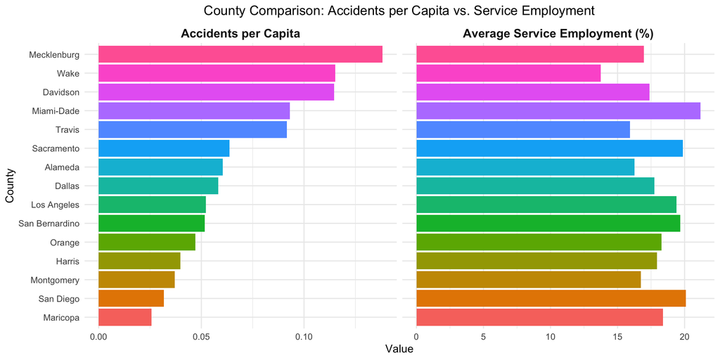

## Data Visualization: Graph of Per Capita and % Office Employment

```r
#Office

selected_counties <- c(
  "Los Angeles", "Miami-Dade", "Orange", "Harris", "Dallas", "Mecklenburg",
  "Montgomery", "Wake", "San Bernardino", "Travis", "Maricopa",
  "San Diego", "Alameda", "Davidson", "Sacramento"
)

office_df <- US_Census_Counties %>%
  filter(County %in% selected_counties) %>%
  group_by(County) %>%
  summarise(Value = mean(Office, na.rm = TRUE)) %>%
  mutate(Metric = "Average Office Employment (%)")

accident_df <- Top_20_Counties_with_Pop %>%
  filter(County %in% selected_counties) %>%
  transmute(County, Value = Accidents_Per_Capita, Metric = "Accidents per Capita")

county_order <- accident_df %>%
  arrange(desc(Value)) %>%
  pull(County)

combined_df <- bind_rows(office_df, accident_df) %>%
  mutate(County = factor(County, levels = rev(county_order)))

ggplot(combined_df, aes(x = County, y = Value, fill = County)) +
  geom_col(show.legend = FALSE) +
  coord_flip() +
  facet_wrap(~ Metric, scales = "free_x", nrow = 1) +
  labs(
    title = "County Comparison: Accidents per Capita vs. Office Employment",
    x = "County",
    y = "Value"
  ) +
  theme_minimal()
```

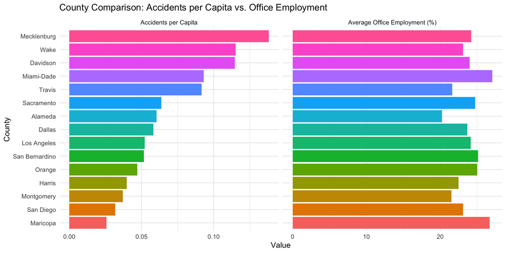

## Data Visualization: Graph of Per Capita and % Who Drive alone

```r
#Drive

drive_df <- US_Census_Counties %>%
  filter(County %in% selected_counties) %>%
  group_by(County) %>%
  summarise(Value = mean(Drive, na.rm = TRUE)) %>%
  mutate(Metric = "Average Drive Alone (%)")

accident_df <- Top_20_Counties_with_Pop %>%
  filter(County %in% selected_counties) %>%
  transmute(County, Value = Accidents_Per_Capita, Metric = "Accidents per Capita")

county_order <- accident_df %>%
  arrange(desc(Value)) %>%
  pull(County)

combined_df <- bind_rows(drive_df, accident_df) %>%
  mutate(County = factor(County, levels = rev(county_order)))

ggplot(combined_df, aes(x = County, y = Value, fill = County)) +
  geom_col(show.legend = FALSE) +
  coord_flip() +
  facet_wrap(~ Metric, scales = "free_x", nrow = 1) +
  labs(
    title = "County Comparison: Accidents per Capita vs. Drive Alone",
    x = "County",
    y = "Value"
  ) +
  theme_minimal()
```

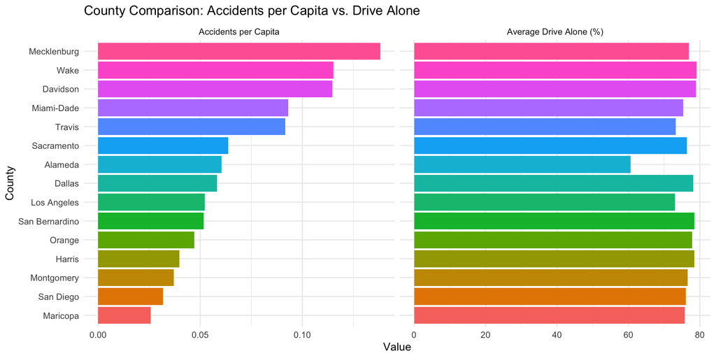

## Data Visualization: Graph of Per Capita and % Commuting with Public Transit

```r
#Transit

transit_df <- US_Census_Counties %>%
  filter(County %in% selected_counties) %>%
  group_by(County) %>%
  summarise(Value = mean(Transit, na.rm = TRUE)) %>%
  mutate(Metric = "Average Public Transit (%)")

accident_df <- Top_20_Counties_with_Pop %>%
  filter(County %in% selected_counties) %>%
  transmute(County, Value = Accidents_Per_Capita, Metric = "Accidents per Capita")

county_order <- accident_df %>%
  arrange(desc(Value)) %>%
  pull(County)

combined_df <- bind_rows(transit_df, accident_df) %>%
  mutate(County = factor(County, levels = rev(county_order)))

ggplot(combined_df, aes(x = County, y = Value, fill = County)) +
  geom_col(show.legend = FALSE) +
  coord_flip() +
  facet_wrap(~ Metric, scales = "free_x", nrow = 1) +
  labs(
    title = "County Comparison: Accidents per Capita vs. Public Transit Usage",
    x = "County",
    y = "Value"
  ) +
  theme_minimal()
```

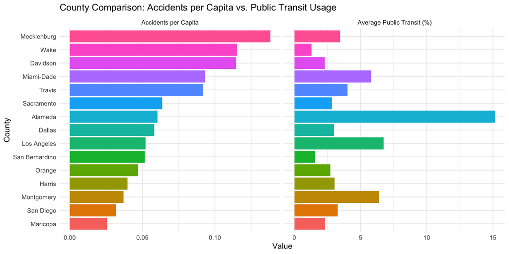

## Data Visualization: Graph of Per Capita and Mean Commute in Minutes

```r
#MeanCommute

commute_df <- US_Census_Counties %>%
  filter(County %in% selected_counties) %>%
  group_by(County) %>%
  summarise(Value = mean(MeanCommute, na.rm = TRUE)) %>%
  mutate(Metric = "Average Commute Time (min)")

accident_df <- Top_20_Counties_with_Pop %>%
  filter(County %in% selected_counties) %>%
  transmute(County, Value = Accidents_Per_Capita, Metric = "Accidents per Capita")

county_order <- accident_df %>%
  arrange(desc(Value)) %>%
  pull(County)

combined_df <- bind_rows(commute_df, accident_df) %>%
  mutate(County = factor(County, levels = rev(county_order)))

ggplot(combined_df, aes(x = County, y = Value, fill = County)) +
  geom_col(show.legend = FALSE) +
  coord_flip() +
  facet_wrap(~ Metric, scales = "free_x", nrow = 1) +
  labs(
    title = "County Comparison: Accidents per Capita vs. Commute Time",
    x = "County",
    y = "Value"
  ) +
  theme_minimal()
```

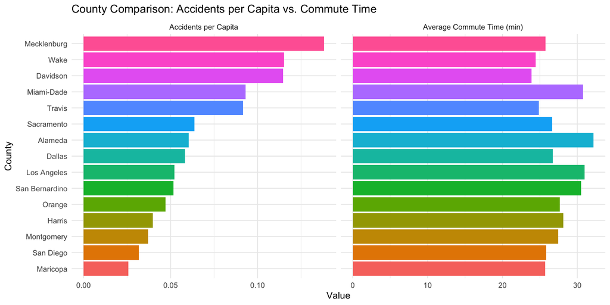

## Scatter Plot Per Capita and Mean Commute

```r
# Step 1: Join commute and accident data directly for scatter plot
selected_counties <- c(
  "Los Angeles", "Miami-Dade", "Orange", "Harris", "Dallas", "Mecklenburg",
  "Montgomery", "Wake", "San Bernardino", "Travis", "Maricopa",
  "San Diego", "Alameda", "Davidson", "Sacramento"
)

# Commute Time
commute_df <- US_Census_Counties %>%
  filter(County %in% selected_counties) %>%
  group_by(County) %>%
  summarise(MeanCommute = mean(MeanCommute, na.rm = TRUE))

# Accidents per Capita
accident_df <- Top_20_Counties_with_Pop %>%
  filter(County %in% selected_counties) %>%
  select(County, Accidents_Per_Capita)

# Combine
joined_df <- left_join(commute_df, accident_df, by = "County")

# Step 2: Scatter plot with regression line
ggplot(joined_df, aes(x = MeanCommute, y = Accidents_Per_Capita, label = County)) +
  geom_point(color = "steelblue", size = 3) +
  geom_smooth(method = "lm", se = TRUE, color = "darkred", linetype = "dashed") +
  geom_text(nudge_y = 0.001, size = 3, check_overlap = TRUE) +
  labs(
    title = "Relationship: Mean Commute Time vs. Accidents per Capita",
    x = "Average Commute Time (min)",
    y = "Accidents per Capita"
  ) +
  theme_minimal()
```

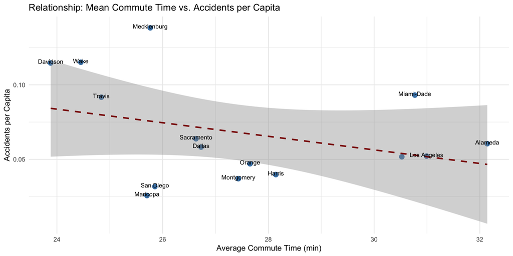

## Scatter Plot Per Capita and Transit

```r
# Scatter Plot: Public Transit (%) vs. Accidents per Capita


selected_counties <- c(
  "Los Angeles", "Miami-Dade", "Orange", "Harris", "Dallas", "Mecklenburg",
  "Montgomery", "Wake", "San Bernardino", "Travis", "Maricopa",
  "San Diego", "Alameda", "Davidson", "Sacramento"
)

# Metric: Public Transit (%)
metric_df <- US_Census_Counties %>%
  filter(County %in% selected_counties) %>%
  group_by(County) %>%
  summarise(MetricValue = mean(Transit, na.rm = TRUE))

# Accidents per Capita
accident_df <- Top_20_Counties_with_Pop %>%
  filter(County %in% selected_counties) %>%
  select(County, Accidents_Per_Capita)

# Combine
joined_df <- left_join(metric_df, accident_df, by = "County")

# Scatter Plot with Best Fit Line
ggplot(joined_df, aes(x = MetricValue, y = Accidents_Per_Capita, label = County)) +
  geom_point(color = "steelblue", size = 3) +
  geom_smooth(method = "lm", se = TRUE, color = "darkred", linetype = "dashed") +
  geom_text(nudge_y = 0.001, size = 3, check_overlap = TRUE) +
  labs(
    title = "Relationship: Public Transit (%) vs. Accidents per Capita",
    x = "Public Transit (%)",
    y = "Accidents per Capita"
  ) +
  theme_minimal()
```

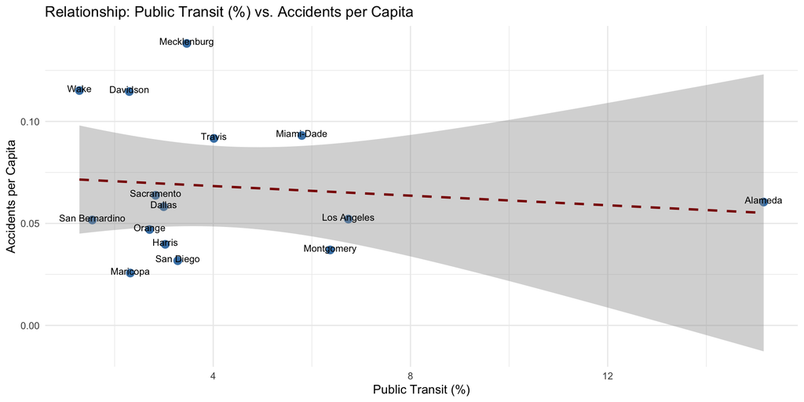

## Scatter Plot Per Capita and Drive

```r
# Scatter Plot: Drive Alone (%) vs. Accidents per Capita


selected_counties <- c(
  "Los Angeles", "Miami-Dade", "Orange", "Harris", "Dallas", "Mecklenburg",
  "Montgomery", "Wake", "San Bernardino", "Travis", "Maricopa",
  "San Diego", "Alameda", "Davidson", "Sacramento"
)

# Metric: Drive Alone (%)
metric_df <- US_Census_Counties %>%
  filter(County %in% selected_counties) %>%
  group_by(County) %>%
  summarise(MetricValue = mean(Drive, na.rm = TRUE))

# Accidents per Capita
accident_df <- Top_20_Counties_with_Pop %>%
  filter(County %in% selected_counties) %>%
  select(County, Accidents_Per_Capita)

# Combine
joined_df <- left_join(metric_df, accident_df, by = "County")

# Scatter Plot with Best Fit Line
ggplot(joined_df, aes(x = MetricValue, y = Accidents_Per_Capita, label = County)) +
  geom_point(color = "steelblue", size = 3) +
  geom_smooth(method = "lm", se = TRUE, color = "darkred", linetype = "dashed") +
  geom_text(nudge_y = 0.001, size = 3, check_overlap = TRUE) +
  labs(
    title = "Relationship: Drive Alone (%) vs. Accidents per Capita",
    x = "Drive Alone (%)",
    y = "Accidents per Capita"
  ) +
  theme_minimal()
```

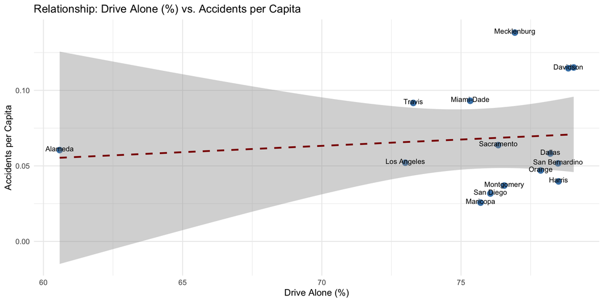

## Scatter Plot Per Capita and Office

```r
# Scatter Plot: Office Employment (%) vs. Accidents per Capita


selected_counties <- c(
  "Los Angeles", "Miami-Dade", "Orange", "Harris", "Dallas", "Mecklenburg",
  "Montgomery", "Wake", "San Bernardino", "Travis", "Maricopa",
  "San Diego", "Alameda", "Davidson", "Sacramento"
)

# Metric: Office Employment (%)
metric_df <- US_Census_Counties %>%
  filter(County %in% selected_counties) %>%
  group_by(County) %>%
  summarise(MetricValue = mean(Office, na.rm = TRUE))

# Accidents per Capita
accident_df <- Top_20_Counties_with_Pop %>%
  filter(County %in% selected_counties) %>%
  select(County, Accidents_Per_Capita)

# Combine
joined_df <- left_join(metric_df, accident_df, by = "County")

# Scatter Plot with Best Fit Line
ggplot(joined_df, aes(x = MetricValue, y = Accidents_Per_Capita, label = County)) +
  geom_point(color = "steelblue", size = 3) +
  geom_smooth(method = "lm", se = TRUE, color = "darkred", linetype = "dashed") +
  geom_text(nudge_y = 0.001, size = 3, check_overlap = TRUE) +
  labs(
    title = "Relationship: Office Employment (%) vs. Accidents per Capita",
    x = "Office Employment (%)",
    y = "Accidents per Capita"
  ) +
  theme_minimal()
```

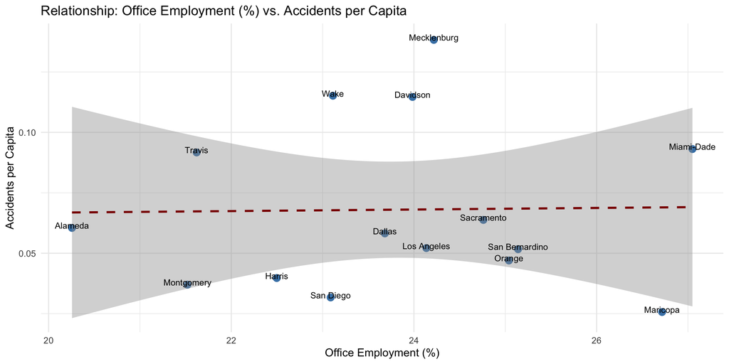

## Scatter Plot Per Capita and Service

```r
# Scatter Plot: Service Employment (%) vs. Accidents per Capita


selected_counties <- c(
  "Los Angeles", "Miami-Dade", "Orange", "Harris", "Dallas", "Mecklenburg",
  "Montgomery", "Wake", "San Bernardino", "Travis", "Maricopa",
  "San Diego", "Alameda", "Davidson", "Sacramento"
)

# Metric: Service Employment (%)
metric_df <- US_Census_Counties %>%
  filter(County %in% selected_counties) %>%
  group_by(County) %>%
  summarise(MetricValue = mean(Service, na.rm = TRUE))

# Accidents per Capita
accident_df <- Top_20_Counties_with_Pop %>%
  filter(County %in% selected_counties) %>%
  select(County, Accidents_Per_Capita)

# Combine
joined_df <- left_join(metric_df, accident_df, by = "County")

# Scatter Plot with Best Fit Line
ggplot(joined_df, aes(x = MetricValue, y = Accidents_Per_Capita, label = County)) +
  geom_point(color = "steelblue", size = 3) +
  geom_smooth(method = "lm", se = TRUE, color = "darkred", linetype = "dashed") +
  geom_text(nudge_y = 0.001, size = 3, check_overlap = TRUE) +
  labs(
    title = "Relationship: Service Employment (%) vs. Accidents per Capita",
    x = "Service Employment (%)",
    y = "Accidents per Capita"
  ) +
  theme_minimal()
```

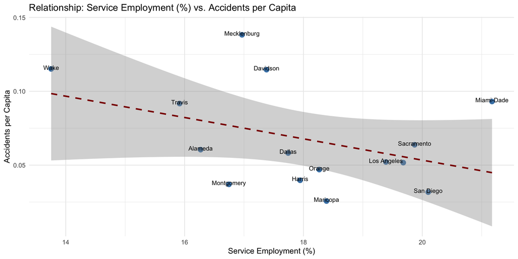

## Scatter Plot Per Capita and Professional

```r
# Scatter Plot: Professional Employment (%) vs. Accidents per Capita


selected_counties <- c(
  "Los Angeles", "Miami-Dade", "Orange", "Harris", "Dallas", "Mecklenburg",
  "Montgomery", "Wake", "San Bernardino", "Travis", "Maricopa",
  "San Diego", "Alameda", "Davidson", "Sacramento"
)

# Metric: Professional Employment (%)
metric_df <- US_Census_Counties %>%
  filter(County %in% selected_counties) %>%
  group_by(County) %>%
  summarise(MetricValue = mean(Professional, na.rm = TRUE))

# Accidents per Capita
accident_df <- Top_20_Counties_with_Pop %>%
  filter(County %in% selected_counties) %>%
  select(County, Accidents_Per_Capita)

# Combine
joined_df <- left_join(metric_df, accident_df, by = "County")

# Scatter Plot with Best Fit Line
ggplot(joined_df, aes(x = MetricValue, y = Accidents_Per_Capita, label = County)) +
  geom_point(color = "steelblue", size = 3) +
  geom_smooth(method = "lm", se = TRUE, color = "darkred", linetype = "dashed") +
  geom_text(nudge_y = 0.001, size = 3, check_overlap = TRUE) +
  labs(
    title = "Relationship: Professional Employment (%) vs. Accidents per Capita",
    x = "Professional Employment (%)",
    y = "Accidents per Capita"
  ) +
  theme_minimal()
```

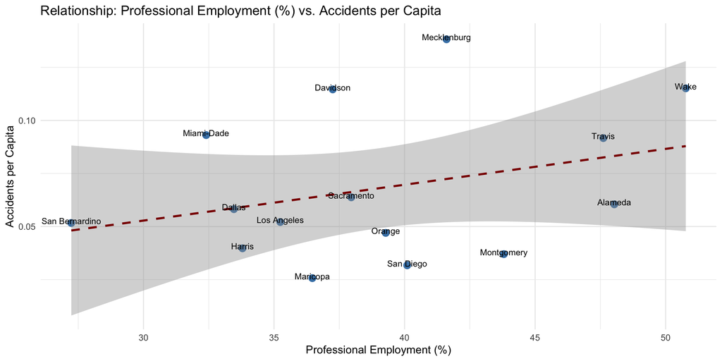

## Scatter Plot Per Capita and Carpool

```r
# Scatter Plot: Carpool (%) vs. Accidents per Capita


selected_counties <- c(
  "Los Angeles", "Miami-Dade", "Orange", "Harris", "Dallas", "Mecklenburg",
  "Montgomery", "Wake", "San Bernardino", "Travis", "Maricopa",
  "San Diego", "Alameda", "Davidson", "Sacramento"
)

# Metric: Carpool (%)
metric_df <- US_Census_Counties %>%
  filter(County %in% selected_counties) %>%
  group_by(County) %>%
  summarise(MetricValue = mean(Carpool, na.rm = TRUE))

# Accidents per Capita
accident_df <- Top_20_Counties_with_Pop %>%
  filter(County %in% selected_counties) %>%
  select(County, Accidents_Per_Capita)

# Combine
joined_df <- left_join(metric_df, accident_df, by = "County")

# Scatter Plot with Best Fit Line
ggplot(joined_df, aes(x = MetricValue, y = Accidents_Per_Capita, label = County)) +
  geom_point(color = "steelblue", size = 3) +
  geom_smooth(method = "lm", se = TRUE, color = "darkred", linetype = "dashed") +
  geom_text(nudge_y = 0.001, size = 3, check_overlap = TRUE) +
  labs(
    title = "Relationship: Carpool (%) vs. Accidents per Capita",
    x = "Carpool (%)",
    y = "Accidents per Capita"
  ) +
  theme_minimal()
```

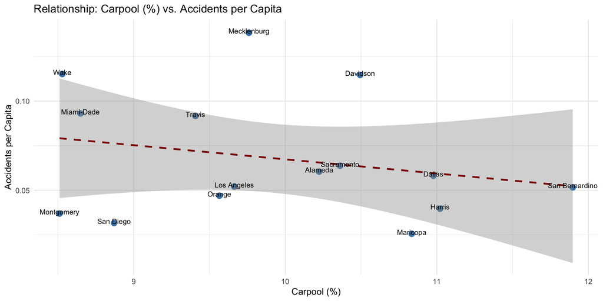

## Scatter Plot Per Capita and WorkAtHome

```r
# Scatter Plot: Work From Home (%) vs. Accidents per Capita

selected_counties <- c(
  "Los Angeles", "Miami-Dade", "Orange", "Harris", "Dallas", "Mecklenburg",
  "Montgomery", "Wake", "San Bernardino", "Travis", "Maricopa",
  "San Diego", "Alameda", "Davidson", "Sacramento"
)

# Metric: Work From Home (%)
metric_df <- US_Census_Counties %>%
  filter(County %in% selected_counties) %>%
  group_by(County) %>%
  summarise(MetricValue = mean(WorkAtHome, na.rm = TRUE))

# Accidents per Capita
accident_df <- Top_20_Counties_with_Pop %>%
  filter(County %in% selected_counties) %>%
  select(County, Accidents_Per_Capita)

# Combine
joined_df <- left_join(metric_df, accident_df, by = "County")

# Scatter Plot with Best Fit Line
ggplot(joined_df, aes(x = MetricValue, y = Accidents_Per_Capita, label = County)) +
  geom_point(color = "steelblue", size = 3) +
  geom_smooth(method = "lm", se = TRUE, color = "darkred", linetype = "dashed") +
  geom_text(nudge_y = 0.001, size = 3, check_overlap = TRUE) +
  labs(
    title = "Relationship: Work From Home (%) vs. Accidents per Capita",
    x = "Work From Home (%)",
    y = "Accidents per Capita"
  ) +
  theme_minimal()
```

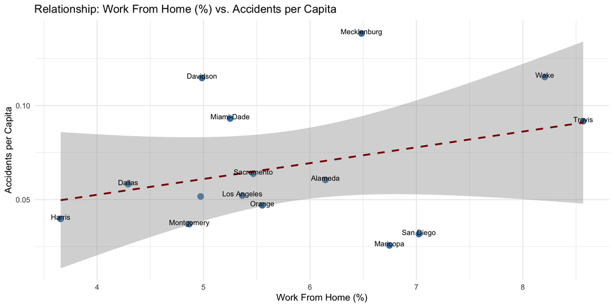

## Scatter Plot Per Capita and Walk

```r
# Scatter Plot: Walk (%) vs. Accidents per Capita


selected_counties <- c(
  "Los Angeles", "Miami-Dade", "Orange", "Harris", "Dallas", "Mecklenburg",
  "Montgomery", "Wake", "San Bernardino", "Travis", "Maricopa",
  "San Diego", "Alameda", "Davidson", "Sacramento"
)

# Metric: Walk (%)
metric_df <- US_Census_Counties %>%
  filter(County %in% selected_counties) %>%
  group_by(County) %>%
  summarise(MetricValue = mean(Walk, na.rm = TRUE))

# Accidents per Capita
accident_df <- Top_20_Counties_with_Pop %>%
  filter(County %in% selected_counties) %>%
  select(County, Accidents_Per_Capita)

# Combine
joined_df <- left_join(metric_df, accident_df, by = "County")

# Scatter Plot with Best Fit Line
ggplot(joined_df, aes(x = MetricValue, y = Accidents_Per_Capita, label = County)) +
  geom_point(color = "steelblue", size = 3) +
  geom_smooth(method = "lm", se = TRUE, color = "darkred", linetype = "dashed") +
  geom_text(nudge_y = 0.001, size = 3, check_overlap = TRUE) +
  labs(
    title = "Relationship: Walk (%) vs. Accidents per Capita",
    x = "Walk (%)",
    y = "Accidents per Capita"
  ) +
  theme_minimal()
```

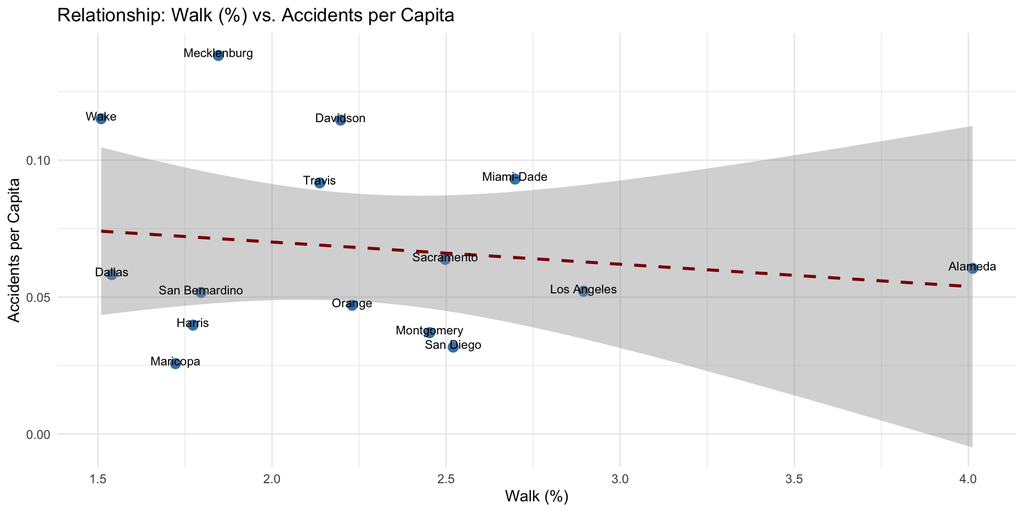

## Table Summary of Research Objective #1

- In conclusion

| Variable | Summary | Accidents Per Capita | Independent Variable |
| --- | --- | --- | --- |
| Top 20 Counties by Accident Count | Los Angeles, Miami-Dade, Orange, Harris, Dallas, etc. |  |  |
| Total Population by County | Nothing of Importance |  |  |
| Top 15 Counties by Accident Count | Had missing data so reduced to top 15 |  |  |
| Top 15 Counties Accidents per Capita | This data was a better representation of how a county is doing |  |  |
| Per Capita and Mean Commute | The worst counties of accidents per capita have the lower average commute | High Rate | Lower Commute |
| Per Capita and Transit | Counties with a higher percentage of public transit have less accidents per capita | Low Rate | High Public Transit |
| Per Capita and One Driver | Accidents per Capita go up as the % of people who drive alone go up | High Rate | High amount of people driving alone |
| Per Capita and people who work in an office | No Findings | No Slope | No Slope |
| Per Capita and Service Workers | A steep decline showing a higher percentage of Service employment relates to a lower Accident rate | Low Rate | High amount of Service Workers |
| Per Capita and Professional Employment | A rise in Professional employment shows a rise in Accidents per capita | High Rate | High Professional Employment |
| Per Capita and those who Carpool | An increase in people who carpool shows a decrease in Accidents per Capita | Low Rate | High Carpool Rates |
| Per Capita and those who work from home | An increase in people working from home shows an increase in Accidents per Capita | High Rate | High amount of people working from home |
| Per Capita and those who walk to work | More people who walk to work shows a decrease in Accidents per Capita | Low Rate | High amount of people walking to work |

## Summary of Research Objective #1

- Accidents per Capita go UP when:
  - Lower Commute times (due to density)
  - More people are driving alone
  - More Professional Employment
  - More People working from home
- Accidents per Capita go DOWN when:
  - Higher amount of Public Transit
  - More Service Workers
  - More people carpooling
  - More people walking to work

## Reference Only

- Refernce data, of bigger data sets
  - US Traffic Accident
    - Data had 7 million rows so I wrangled the data and only kept sums and tables I needed -US Census Data
    - Originally had 100,000 rows and wrangled it down to 14,000 rows which is all i needed based on the counties i found in the US traffic Accident data

```r
#Read Census data
#US_Census_Data <- read_csv("2017 Census Data.csv")

#head(US_Census_Data)

# Remove the word "County" and trim any extra whitespace
#US_Census_Data$County <- gsub("County", "", US_Census_Data$County)
#US_Census_Data$County <- trimws(US_Census_Data$County)

# Clean list of counties (de-duplicated and trimmed)
#target_counties <- c(
  #"Los Angeles", "Miami-Dade", "Orange", "Harris", "Dallas",
  #"Mecklenburg", "Montgomery", "Wake", "San Bernardino", "Travis",
  #"Maricopa", "San Diego", "Alameda", "Davidson", "Sacramento",
 # "Riverside", "East Baton Rouge", "Santa Clara", "Cook", "Marion",
  #"Fulton", "Jefferson", "Washington", "Jackson", "Pima", "Greenville",
 # "El Paso"
#)

# Create a new dataset with only those counties
#filtered_census_data <- US_Census_Data %>%
 # filter(County %in% target_counties)

#print(filtered_census_data)

#write.csv(filtered_census_data, "US_Census_Counties.csv", row.names = FALSE)
```

```r
# Ensure Severity is treated as a factor
#US_Accident_Data$Severity <- as.factor(US_Accident_Data$Severity)

# Function to get top 10 counties for a given severity level
#get_top_counties_by_severity <- function(severity_level) {
 # US_Accident_Data %>%
    #filter(Severity == severity_level) %>%
    #count(County, sort = TRUE) %>%
    #top_n(10, n) %>%
   # arrange(desc(n)) %>%
   # rename(Accident_Count = n)
#}

# Create datasets
#top_counties_sev1 <- get_top_counties_by_severity("1")
#top_counties_sev2 <- get_top_counties_by_severity("2")
#top_counties_sev3 <- get_top_counties_by_severity("3")
#top_counties_sev4 <- get_top_counties_by_severity("4")

# Export to CSV files
#write.csv(top_counties_sev1, "top_counties_severity1.csv", row.names = FALSE)
#write.csv(top_counties_sev2, "top_counties_severity2.csv", row.names = FALSE)
#write.csv(top_counties_sev3, "top_counties_severity3.csv", row.names = FALSE)
#write.csv(top_counties_sev4, "top_counties_severity4.csv", row.names = FALSE)
```